# SDS 192: Homework #6

Sabrina Sayasith

Due: 4/15/16

These problems will require that you query the IMDB database located on `scidb`. The easiest way to obtain access is to run the following:

```r
library(mdsr)
library(DBI)
library(RMySQL)
db <- dbConnect_scidb(dbname = "imdb")
```

You will also need the `RMySQL` package installed. Note that `db` is now a `MySQLConnection` object.

```r
class(db)
```

```
## [1] "MySQLConnection"
## attr(,"package")
## [1] "RMySQL"
```

To retrieve the results from a query in R, use the `dbGetQuery` function from the `DBI` package. Its first argument is a database connection object, and the second is an SQL query as a character vector.

```r
db %>%
  dbGetQuery("SELECT * FROM kind_type;")
```

```
##   id           kind
## 1  1          movie
## 2  2      tv series
## 3  3       tv movie
## 4  4    video movie
## 5  5 tv mini series
## 6  6     video game
## 7  7        episode
```

#### Problem 1

According to the Wikipedia, the first film to earn an NC-17 rating from the MPAA was [Henry & June (1990)](https://en.wikipedia.org/wiki/Henry_%26_June). However, that is not the NC-17 film with the earliest `production_year` in the IMDB. Write a query that returns the list of *feature-length* NC-17 movies. What are the main reasons given for NC-17 ratings?

> Hint: Note that both `info_type = LD certification` and `info_type = mpaa` can contain MPAA ratings.

```r
sql <- "
SELECT t.title, t.production_year, mii.info AS description
FROM title t
JOIN movie_info mii ON mii.movie_id = t.id
WHERE t.kind_id = 1
AND mii.info_type_id = 97
AND mii.info LIKE '%NC-17%'
ORDER BY t.production_year;
"

db %>%
  dbGetQuery(sql)
```

```
##                                       title production_year
## 1                          Tropic of Cancer            1970
## 2                            Pink Flamingos            1972
## 3                     Ultimo tango a Parigi            1972
## 4                          La grande bouffe            1973
## 5                            Female Trouble            1974
## 6                              Histoire d'O            1975
## 7                                   Inserts            1975
## 8                             The Evil Dead            1981
## 9                                   Matador            1986
## 10                         La ley del deseo            1987
## 11             La storia di Lady Chatterley            1989
## 12                             Santa sangre            1989
## 13                                   Átame!            1989
## 14                              Hard to Die            1990
```

[output cut: 99 more lines]

The NC-17 film with the earliest “production_year” is “Tropic of Cancer” with a “production_year” of 1970. The main reasons given for NC-17 ratings are explicit sexual content and explicit sexuality.

Bonus: cull the list to English-language films only.

```r
sqlEng <- "
SELECT t.title, t.production_year, mii.info, mi.info
FROM title t
JOIN movie_info mii ON mii.movie_id = t.id
JOIN movie_info mi ON mi.movie_id = t.id
WHERE t.kind_id = 1
AND mii.info_type_id = 97
AND mi.info_type_id = 4
AND mi.info LIKE '%English%'
AND mii.info LIKE '%NC-17%'
ORDER BY t.production_year;
"

engNC17<- db %>%
  dbGetQuery(sqlEng)
```

#### Problem 2

The 1992 Clint Eastwood western *Unforgiven* is often credited for reviving the Western genre.

1. Compute the number of Western for each `production_year`. Your result should be a `data.frame` with two columns: `production_year` and `numWesterns`.

```r
sql2 <- "
SELECT t.production_year, sum(1) as numWesterns
FROM title t
JOIN movie_info mi on t.id = mi.movie_id
WHERE mi.info_type_id = 3
AND mi.info like 'Western'
AND t.kind_id = 1
GROUP BY t.production_year
"

westerns <- db %>%
  dbGetQuery(sql2)
westerns
```

```
##     production_year numWesterns
## 1                NA         219
## 2              1894           1
## 3              1899           4
## 4              1901           1
## 5              1903           8
## 6              1904           4
## 7              1905           3
## 8              1906           8
## 9              1907          20
## 10             1908          49
## 11             1909         107
## 12             1910         387
## 13             1911         518
## 14             1912         579
```

[output cut: 107 more lines]

1. Compute the number of all films for each `production_year`. Your result should be a `data.frame` with two columns: `production_year` and `N`.

```r
sql3 <- "
SELECT t.production_year, sum(1) as N
FROM title t
JOIN movie_info mi on t.id = mi.movie_id
WHERE mi.info_type_id = 3
AND t.kind_id = 1
GROUP BY t.production_year
"

allFilms <- db %>%
  dbGetQuery(sql3)
allFilms
```

```
##     production_year      N
## 1                NA  42078
## 2              1874      2
## 3              1878      1
## 4              1883      1
## 5              1887      1
## 6              1888      8
## 7              1889      3
## 8              1890      9
## 9              1891     16
## 10             1892     19
## 11             1893      3
## 12             1894    142
## 13             1895    197
## 14             1896   1466
```

[output cut: 129 more lines]

1. Join the results from the previous two questions on `production_year`. Compute the percentage of movies in each year that are Westerns.

```r
joinedFilmCount <- inner_join(westerns, allFilms, by = "production_year")
joinedFilmCount <- joinedFilmCount %>%
  mutate(percWestern = (numWesterns/N)*100)
joinedFilmCount
```

```
##     production_year numWesterns      N percWestern
## 1                NA         219  42078  0.52046200
## 2              1894           1    142  0.70422535
## 3              1899           4   3535  0.11315417
## 4              1901           1   3472  0.02880184
## 5              1903           8   5113  0.15646392
## 6              1904           4   3400  0.11764706
## 7              1905           3   3214  0.09334163
## 8              1906           8   3475  0.23021583
## 9              1907          20   4522  0.44228218
## 10             1908          49   7601  0.64465202
## 11             1909         107   9565  1.11866179
## 12             1910         387  11799  3.27993898
## 13             1911         518  11672  4.43797121
## 14             1912         579  15708  3.68601986
```

[output cut: 107 more lines]

1. Plot the percentage of films that are Westerns as a time series. Annotate your plot with the year in which *Unforgiven* was made. Do you find any evidence to suggest that *Unforgiven* revived the Western?

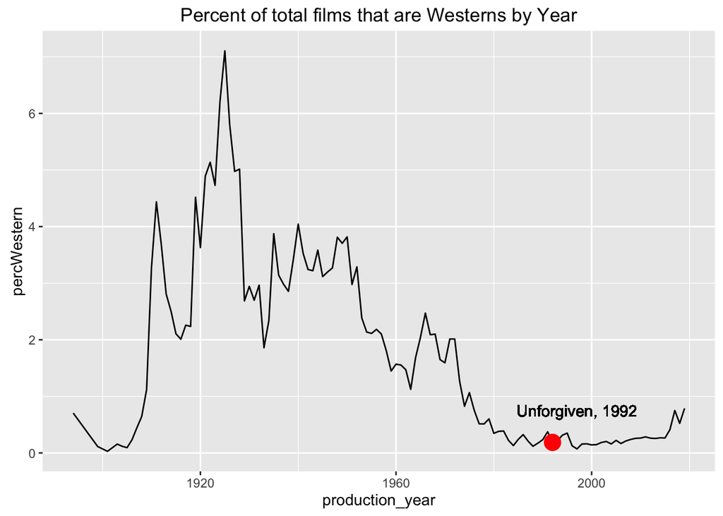

```r
#1992 Unforgiven
percWesternPlot <- ggplot(data = joinedFilmCount, aes(x = production_year, y = percWestern))
percWesternPlot + geom_line() + ggtitle("Percent of total films that are Westerns by Year") + geom_point(data = joinedFilmCount[94:94, ], aes(x = production_year, y = percWestern), colour = "red", size = 5 ) + geom_text(aes(1997, 0.75), label = "Unforgiven, 1992")
```

It seems that there was a tiny rise in the percentage of Westerns made after *Unforgiven*, but it does not seem large enough to be a revival of the genre. The percentage still stays incredibly low compared to more popular times.